# Week 4 Homework: The Bootstrap

Dennis Murray

June 1, 2016

## The Central Limit Theorem

The important findings of the Central Limit Theorem state that the “…the mean of the sampling distribution of the average is also mu, the standard deviation of the sampling distribution is sigma divided by the square root of n, and the shape of the distribution is more nearly normal than is the shape of the population distribution.” (The Statistical Sleuth by Ramsey and Schaefer, page 33)

## Normal Distribution with Sample Size of 15

My first test will be with a sample size of 15, a mean of 20, and standard deviation of 10.

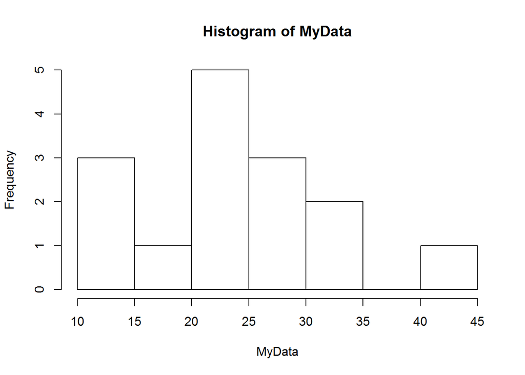

```r
MyData<-rnorm(15,20,10)
hist(MyData)
```

I’m going to take some descriptive statistics about the normally distributed data. We will use those later to measure against.

```r
StdErrorMyData<-sd(MyData)/sqrt(length(MyData))
SampleVarianceMyData<-var(MyData)
mean(MyData)
```

```
## [1] 23.95629
```

```r
sd(MyData)
```

```
## [1] 8.438962
```

Now I’ll boostrap the small sample into 1000 repititions of the data.

```r
#r is the repititions we will run
r<-1000

#s is the size of the sample we will take
s<-length(MyData)

#i is a counter for the loop
i<-1

#place to store the means
SampleMeans<-c()

#loop to repetitively take a sample
while(i<=r)
  {
SampleMyData<-sample(MyData,size = s,replace=TRUE)

#append SampleMyData to all of the SampleMeans
SampleMeans<-c(SampleMeans, mean(SampleMyData))

i<-i+1
}
```

Let’s review what the data now looks like.

Can we show that the sampling distribution is more nearly normal? The histogram will show this.

Can we satisfy the other two specifications that were set forth in the Statistical Sleuth for the Central Limit Theorem?

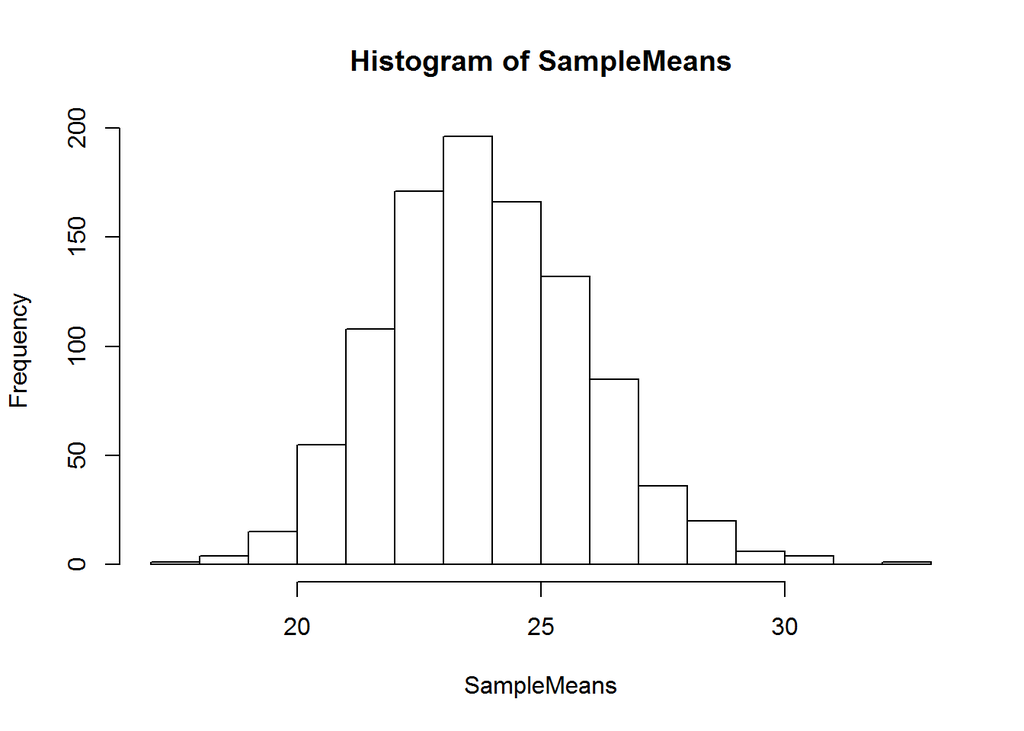

```r
hist(SampleMeans)
```

```r
mean(SampleMeans)
```

```
## [1] 23.85993
```

```r
mean(MyData)
```

```
## [1] 23.95629
```

```r
sd(SampleMeans)
```

```
## [1] 2.075065
```

```r
sd(MyData)/sqrt(length(MyData))
```

```
## [1] 2.178931
```

In this case, the quantities reported are similar but not identical.

## Normal Distribution with Sample Size of 500

My second test will be with a sample size of 500, a mean of 20, and standard deviation of 10.

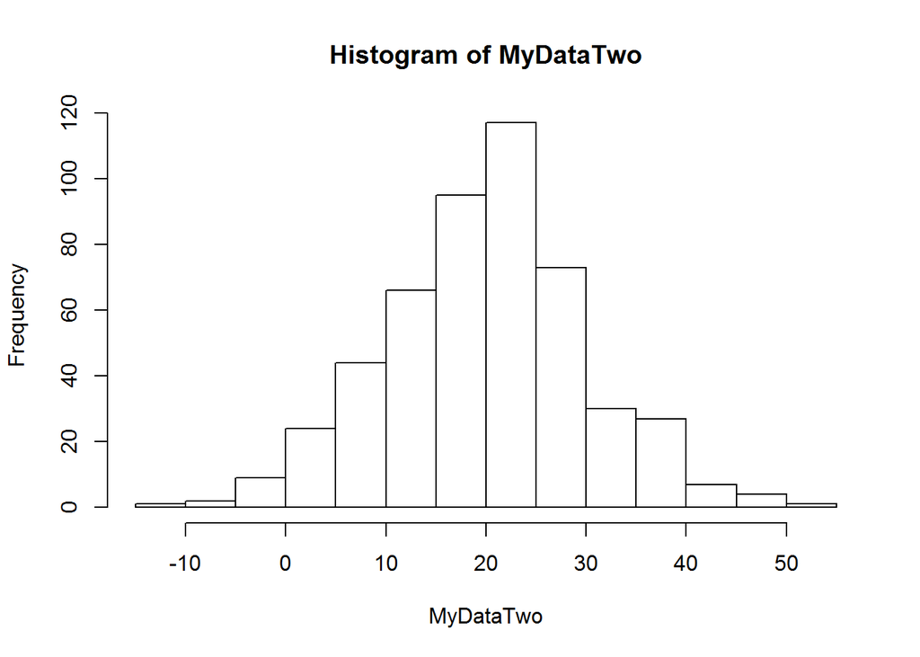

```r
MyDataTwo<-rnorm(500,20,10)
hist(MyDataTwo)
```

The result this time is definitely more normal to begin with, but is still less than symmetrical.

I’m going to take some descriptive statistics about the normally distributed data. We will use those later to measure against.

```r
StdErrorMyDataTwo<-sd(MyDataTwo)/sqrt(length(MyDataTwo))
SampleVarianceMyDataTwo<-var(MyDataTwo)
mean(MyDataTwo)
```

```
## [1] 19.88024
```

```r
sd(MyDataTwo)
```

```
## [1] 10.00633
```

Now I’ll boostrap the larger sample into 1000 repititions of the data.

```r
#r is the repititions we will run
r<-1000

#s is the size of the sample we will take
s<-length(MyDataTwo)

#i is a counter for the loop
i<-1

#place to store the means
SampleMeansTwo<-c()

#loop to repetitively take a sample
while(i<=r)
  {
SampleMyDataTwo<-sample(MyDataTwo,size = s,replace=TRUE)

#append SampleMyData to all of the SampleMeans
SampleMeansTwo<-c(SampleMeansTwo, mean(SampleMyDataTwo))

i<-i+1
}
```

Let’s review what the data now looks like. It has moved closer to a normal distribution.

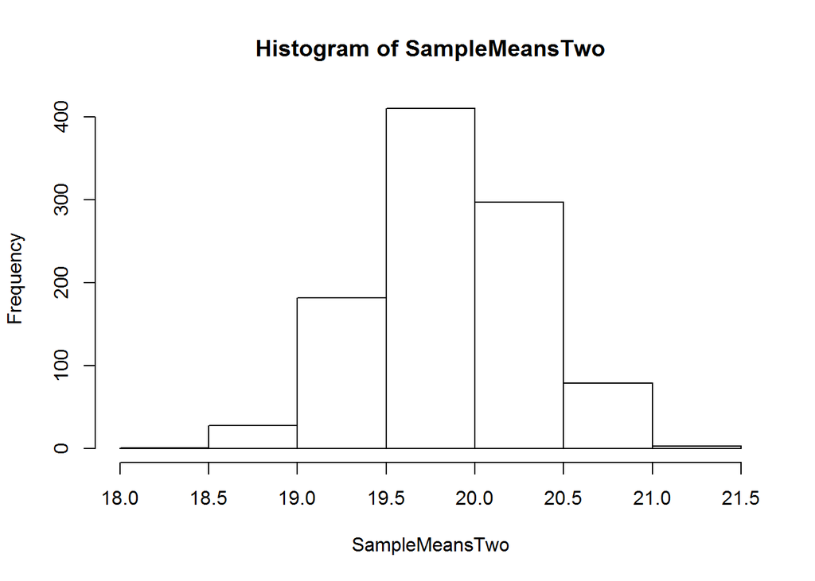

```r
hist(SampleMeansTwo)
```

```r
mean(SampleMeansTwo)
```

```
## [1] 19.86397
```

```r
mean(MyDataTwo)
```

```
## [1] 19.88024
```

```r
sd(SampleMeansTwo)
```

```
## [1] 0.4503865
```

```r
sd(MyDataTwo)/sqrt(length(MyDataTwo))
```

```
## [1] 0.4474966
```

The means are nearly identical, and the standard deviation of the sample is close to the defined value of sigma divided by the square root of n.

## Exponential Distribution with Sample Size of 15

The second part of the problem asks us to repeat, with an exponential distribution. I’ll use 15 as the size of my data this time.

```r
MyDataThree<-rexp(15)
```

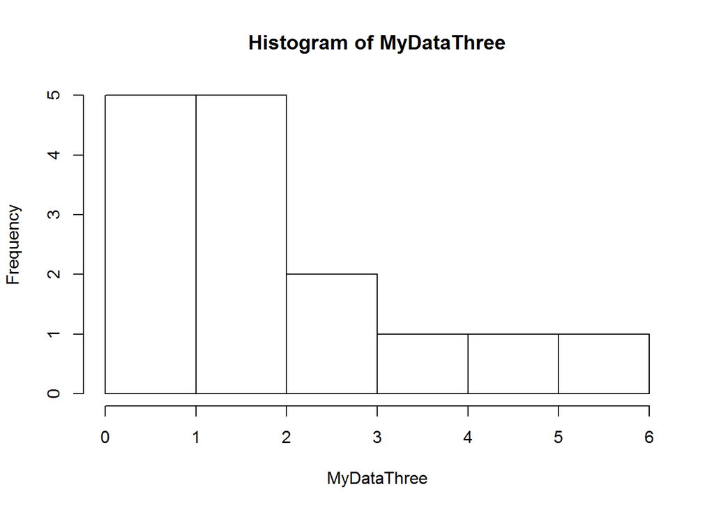

```r
hist(MyDataThree)
```

```r
MeanMyDataThree<-mean(MyDataThree)
StdErrorMyDataThree<-sd(MyDataThree)/sqrt(length(MyDataThree))
SampleVarianceMyDataThree<-var(MyDataThree)
sd(MyDataThree)
```

```
## [1] 1.684103
```

The small sample has left us with less than a perfect exponential distribution.

```r
#r is the repititions we will run
r<-1000

#s is the size of the sample we will take
s<-length(MyDataThree)

#i is a counter for the loop
i<-1

#place to store the means
SampleMeansThree<-c()

#loop to repetitively take a sample
while(i<=r)
{
  SampleMyDataThree<-sample(MyDataThree,size = s,replace=TRUE)

  #append SampleMyDataThree to all of the SampleMeans
  SampleMeansThree<-c(SampleMeansThree, mean(SampleMyDataThree))

  i<-i+1
}
```

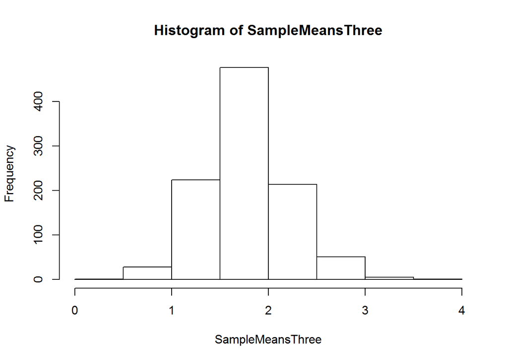

```r
hist(SampleMeansThree)
```

Again the bootstrap has provided us a sample mean distribution that is closer to the normal distribution.

```r
mean(SampleMeansThree)
```

```
## [1] 1.767461
```

```r
mean(MyDataThree)
```

```
## [1] 1.781211
```

```r
sd(SampleMeansThree)
```

```
## [1] 0.4340397
```

```r
sd(MyDataThree)/sqrt(length(MyDataThree))
```

```
## [1] 0.4348336
```

And again we’ve come to a conclusion where our means and standard deviations are very close.

## Exponential Distribution for Population 1500

```r
MyDataFour<-rexp(1500)
```

With a larger size for this random exponential distribution, it’s much closer to what we would expect as ideal.

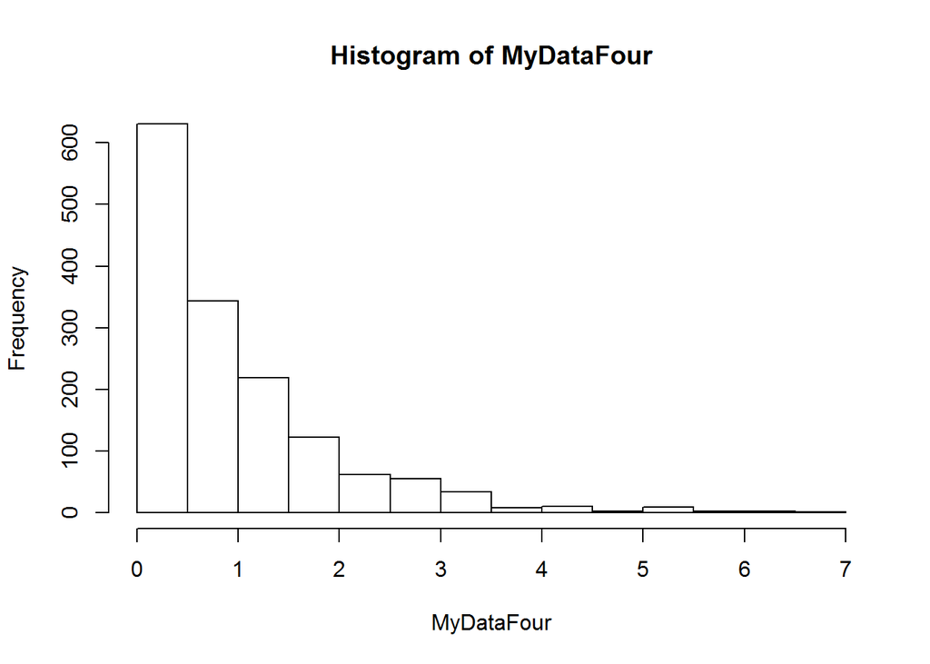

```r
hist(MyDataFour)
```

```r
MeanMyDataFour<-mean(MyDataFour)
StdErrorMyDataFour<-sd(MyDataFour)/sqrt(length(MyDataFour))
SampleVarianceMyDataFour<-var(MyDataFour)
sd(MyDataFour)
```

```
## [1] 0.9719755
```

```r
#r is the repititions we will run
r<-1000

#s is the size of the sample we will take
s<-length(MyDataFour)

#i is a counter for the loop
i<-1

#place to store the means
SampleMeansFour<-c()

#loop to repetitively take a sample
while(i<=r)
{
  SampleMyDataFour<-sample(MyDataFour,size = s,replace=TRUE)

  #append SampleMyDataFour to all of the SampleMeans
  SampleMeansFour<-c(SampleMeansFour, mean(SampleMyDataFour))

  i<-i+1
}
```

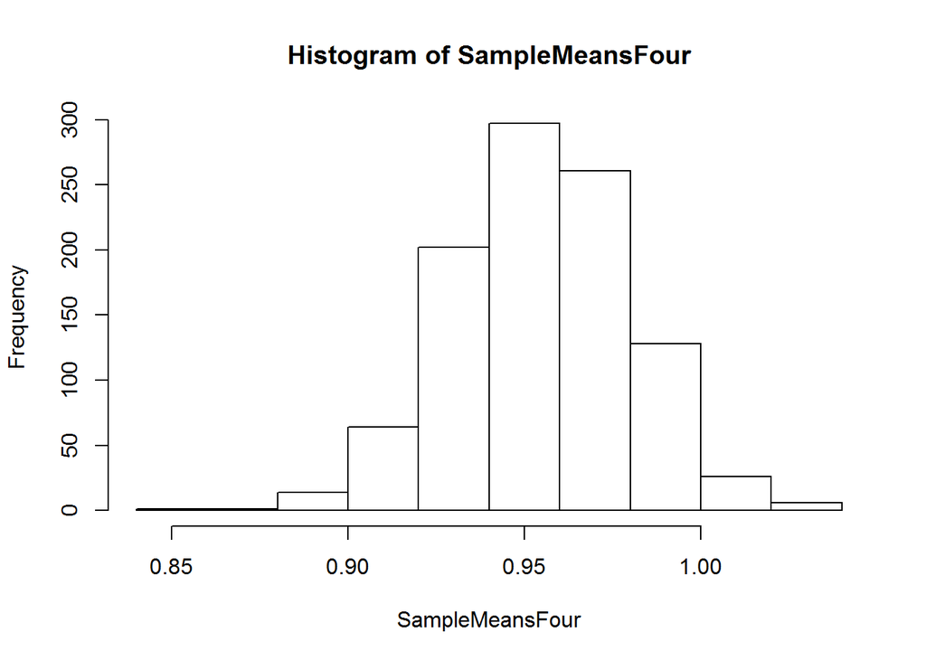

```r
hist(SampleMeansFour)
```

Again the bootstrap has provided us a sample mean distribution that is closer to the normal distribution.

```r
mean(SampleMeansFour)
```

```
## [1] 0.9549357
```

```r
mean(MyDataFour)
```

```
## [1] 0.9542704
```

```r
sd(SampleMeansFour)
```

```
## [1] 0.0253704
```

```r
sd(MyDataFour)/sqrt(length(MyDataFour))
```

```
## [1] 0.0250963
```

And again we’ve come to a conclusion where our means and standard deviations are very close.